# Information and Entropy

Lecture 19

March 9, 2026

# Last Class

## What Makes A Good Prediction?

What do we want to see in a probabilistic projection $F$?

- **Calibration**: Does the predicted CDF $F(y)$ align with the “true” distribution of observations $y$?
  $$\mathbb{P}(y \leq F^{-1}(\tau)) = \tau \qquad \forall \tau \in [0, 1]$$
- **Dispersion**: Is the concentration (variance) of $F$ aligned with the concentration of observations?
- **Sharpness**: How concentrated are the forecasts $F$?

## Probability Integral Transform (PIT)

Common to use the PIT to make these more concrete: $Z_F = F(y)$.

The forecast is **probabilistically calibrated** if $Z_F \sim Uniform(0, 1)$.

The forecast is **properly dispersed** if $\text{Var}(Z_F) = 1/12$.

**Sharpness** can be measured by the width of a particular prediction interval. **A good forecast is a sharp as possible subject to calibration** (Gneiting et al., 2007).

## Scoring Rules

A scoring rule $S(F, y)$ measures the “loss” of a predicted probability distribution $F$ once an observation $y$ is obtained.

**Proper** scoring rules are minimized when the forecasted distribution matches the observed distribution:

$$\mathbb{E}_Y(S(G, G)) \leq \mathbb{E}_Y(S(F, G)) \qquad \forall F.$$

## $k$-Fold Cross-Validation

What if we repeated this procedure for multiple held-out sets?

1. Randomly split data into $k = n / m$ equally-sized subsets.
2. For each $i = 1, \ldots, k$, fit model to $y_{-i}$ and test on $y_i$.

If data are large, this is a good approximation.

## LOO-CV Algorithm

1. Drop one value $y_i$.
2. Refit model on rest of data $y_{-i}$.
3. Predict dropped point $p(\hat{y}_i | y_{-i})$.
4. Evaluate score on dropped point ($\log p(y_i | y_{-i})$).
5. Repeat on rest of data set.

# Information and Uncertainty

## Interpreting Scores

When directly comparing models, this can be straightforward: lower (usually) score => better.

But this doesn’t tell us anything about whether a particular score is good or even acceptable: How do we quantify the “distance” from “perfect” prediction?

## Uncertainty and Information

More uncertainty ⇒ predictions are more difficult.

One approach: quantify **information** as the reduction in uncertainty conditional on a prediction or projection.

**Example**: Perfect prediction ⇒ complete reduction in uncertainty (observation will always match prediction).

## Quantifying Uncertainty

What properties should a measure of uncertainty possess?

1. Should be continuous wrt probabilities;
2. Should increase with number of possible events;
3. Should be additive.

## Entropy

It turns out there is only one function which satisfies these conditions: **Information Entropy** (Shannon, 1948)

$$H(p) = -\mathbb{E}(\log(p_i)) = - \sum_{i=1}^n p_i \log p_i$$

The entropy (or uncertainty) of a probability distribution is the average log-probability of an event.

## Entropy Example

Suppose in Ithaca we have “true” probabilities of rain, sunshine, and fog which are 0.55, 0.2, and 0.25.

$$H(p) = -(0.55 \log(0.55) + 0.2 \log(0.2) + 0.25\log(0.25) \approx 1.0$$

## Entropy Example

Now suppose in Dubai these probabilities are 0.01, 0.95, and 0.04, respectively.

$$H(p) = -(0.01 \log(0.01) + 0.95 \log(0.95) + 0.04\log(0.04) \approx 0.22$$

$H$ is lower in Dubai than in Ithaca because there is **less uncertainty about the outcome** on a given day.

## Maximum Entropy

As an aside, what distribution maximizes entropy (has the most uncertainty subject to its constraints)?

This is equivalent to a distribution being the “least informative” given a set of constraints.

Can think of this as being the distribution which can emerge through the greatest combination of data-generating events.

## Maximum Entropy Examples

1. From the Central Limit Theorem, Gaussians emerge as the limit of sums of arbitrary random variables with finite mean and variance.

   This is equivalent to Gaussians as the entropy-maximizing distribution for a given (finite) mean and variance.
2. Binomial distributions maximize entropy under the assumptions of two outcomes with constant probabilities.

This is where generalized linear models come from!

## From Entropy to Accuracy

**Entropy**: Measure of uncertainty across a distribution $p$.

**Divergence**: Uncertainty induced by using probabilities from one distribution $q$ to describe outcomes from another “true” distribution $p$.

The lower the divergence between a predictive distribution $q$ and a “true” distribution $p$, the more “skill” $q$ has.

## Kullback-Leibler Divergence

One way to formalize divergence: how much additional entropy (uncertainty) is introduced by using a model $q$ instead of the true target $p$?

$$D_{KL}(p, q) = \sum_i p_i (\log(p_i) - \log(q_i)) = \sum_i p_i \log\left(\frac{p_i}{q_i}\right)$$

Thus the “divergence” (intuitively: distance) between two distributions is the **average difference in log-probabilities between the target $p$ and the model $q$**.

## K-L Divergence Example

Suppose the “true” probability of rain is $p(\text{Rain}) = 0.65$ and the “true” probability of $p(\text{Sunshine})=0.35$.

What happens as we change $q(\text{Rain})$?

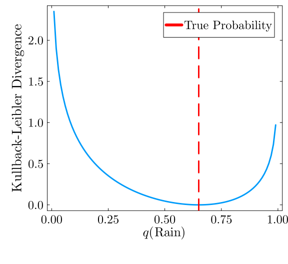

Figure 1: Example of K-L Divergence

```julia
p_true = [0.65, 0.35]
q_rain = 0.01:0.01:0.99

function kl_divergence_2outcome(p, q)
    div_diff = log.(p) .- log.(q)
    return sum(p .* div_diff)
end

kl_out(q) = kl_divergence_2outcome(p_true, [q, 1 - q])
plot(q_rain, kl_out.(q_rain), lw=3, label=false, ylabel="Kullback-Leibler Divergence", xlabel=L"$q(\textrm{Rain})$")
vline!([p_true[1]], lw=3, color=:red, linestyle=:dash, label="True Probability")
plot!(size=(600, 550))
```

## K-L Divergence Is Not Symmetric

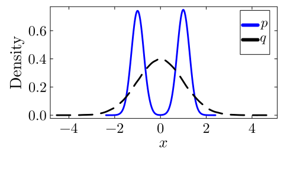

Figure 2: Lack of symmetry of the K-L Divergence

```julia
p = MixtureModel(Normal, [(-1, 0.25), (1, 0.25)], [0.5, 0.5])
psamp = rand(p, 100_000)
q = Normal(0, 1)
qsamp = rand(q, 100_000)

# Monte Carlo estimation of K-L Divergence
kl_pq = mean(logpdf.(p, psamp) .- logpdf.(q, psamp))
kl_qp = mean(logpdf.(q, qsamp) .- logpdf.(p, qsamp))
p1 = density(psamp, lw=3, label=L"$p$", color=:blue, xlabel=L"$x$", ylabel="Density")
density!(p1, qsamp, lw=3, label=L"$q$", color=:black, linestyle=:dash)
plot!(p1, size=(500, 300))
```

$D_{KL}(p, q) =$ 0.72

$D_{KL}(q, p) =$ 2.02

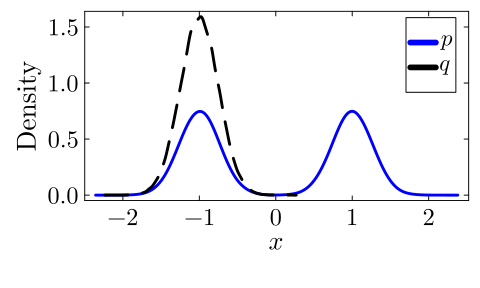

Figure 3: Lack of symmetry of the K-L Divergence

```julia
p = MixtureModel(Normal, [(-1, 0.25), (1, 0.25)], [0.5, 0.5])
psamp = rand(p, 100_000)
q = Normal(-1, 0.25)
qsamp = rand(q, 100_000)

# Monte Carlo estimation of K-L Divergence
kl_pq = mean(logpdf.(p, psamp) .- logpdf.(q, psamp))
kl_qp = mean(logpdf.(q, qsamp) .- logpdf.(p, qsamp))
p2 = density(psamp, lw=3, label=L"$p$", color=:blue, xlabel=L"$x$", ylabel="Density")
density!(p2, qsamp, lw=3, label=L"$q$", color=:black, linestyle=:dash)
plot!(p2, size=(500, 300))
```

$D_{KL}(p, q) =$ 15.26

$D_{KL}(q, p) =$ 0.69

## Divergence for Model Comparison

**So Far**: Divergence as measure of lack of accuracy.

But we never know the “true” distribution of outcomes.

It turns out we rarely need to do this: no model will be “right,” so we’re often interested in comparing two candidate models $q$ and $r$.

## Divergence for Model Comparison

What is the difference between $D_{KL}(p, q)$ and $D_{KL}(p, r)$?

$$D_{KL}(p, q) - D_{KL}(p, r) = \sum_i p_i (\log(r_i) - \log(q_i))$$

We don’t know $p_i$, but comparing the logarithmic scores $S(r) = \sum_i \log(r_i)$ and $S(q) = \sum_i \log(q_i)$ gives us an approximation.

## Deviance Scale

This **log-predictive-density** score is better when larger.

Common to see this converted to **deviance**, which is $-2\text{lppd}$:

- $-1$ reorients so smaller is better;
- Multiplied by $2$ for historical reasons (cancels out the -1/2 in the Gaussian likelihood).

# Overfitting and Deviance

## Importance of Holding Out Data

- Training data contains information about those predictions (reducing cross-entropy).
- Testing model on training data therefore isn’t a test of “pure” prediction.

## Deviance and Degrees of Freedom

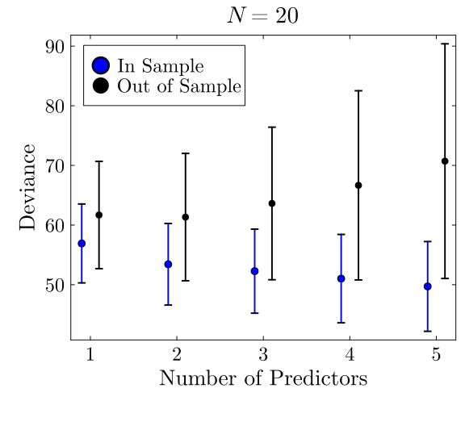

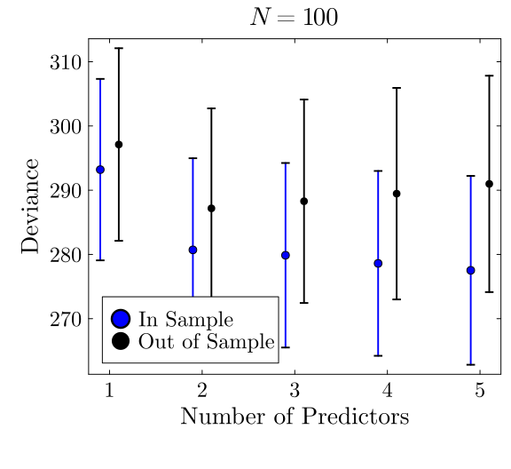

(b)

Figure 4

```julia
function calculate_deviance(y_gen, x_gen, y_oos, x_oos; degree=2, reg=Inf)
    # fit model
    lb = [-5 .+ zeros(degree); 0.01]
    ub = [5 .+ zeros(degree); 10.0]
    p0 = [zeros(degree); 5.0]

    function model_loglik(p, y, x, reg)
        if mean(p[1:end-1]) <= reg
            ll = 0
            for i = 1:length(y)
                μ = sum(x[i, 1:degree] .* p[1:end-1])
                ll += logpdf(Normal(μ, p[end]), y[i])
            end
        else
            ll = -Inf
        end
        return ll
    end

    result = optimize(p -> -model_loglik(p, y_gen, x_gen, reg), lb, ub, p0)
    θ = result.minimizer

    function deviance(p, y_pred, x_pred)
        dev = 0
        for i = 1:length(y_pred)
            μ = sum(x_pred[i, 1:degree] .* p[1:end-1])
            dev += -2 * logpdf(Normal(μ, p[end]), y_pred[i])
        end
        return dev
    end

    dev_is = deviance(θ, y_gen, x_gen)
    dev_oos = deviance(θ, y_oos, x_oos)
    return (dev_is, dev_oos)
end


N_sim = 10_000

function simulate_deviance(N_sim, N_data; reg=Inf)
    d_is = zeros(5, 4)
    for d = 1:5
        dev_out = zeros(N_sim, 2)
        for n = 1:N_sim
            x_gen = rand(Uniform(-2, 2), (N_data, 5))
            μ_gen = [0.1 * x_gen[i, 1] - 0.3 * x_gen[i, 2] for i in 1:N_data]
            y_gen = rand.(Normal.(μ_gen, 1))

            x_oos = rand(Uniform(-2, 2), (N_data, 5))
            μ_oos = [0.1 * x_oos[i, 1] - 0.3 * x_oos[i, 2] for i in 1:N_data]
            y_oos = rand.(Normal.(μ_oos, 1))

            dev_out[n, :] .= calculate_deviance(y_gen, x_gen, y_oos, x_oos, degree=d, reg=reg)
        end
        d_is[d, 1] = mean(dev_out[:, 1])
        d_is[d, 2] = std(dev_out[:, 1])
        d_is[d, 3] = mean(dev_out[:, 2])
        d_is[d, 4] = std(dev_out[:, 2])
    end
    return d_is
end

d_20 = simulate_deviance(N_sim, 20)
p1 = scatter(collect(1:5) .- 0.1, d_20[:, 1], yerr=d_20[:, 2], color=:blue, linecolor=:blue, lw=2, markersize=5, label="In Sample", xlabel="Number of Predictors", ylabel="Deviance", title=L"$N = 20$")
scatter!(p1, collect(1:5) .+ 0.1, d_20[:, 3], yerr=d_20[:, 4], lw=2, markersize=5, color=:black, linecolor=:black, label="Out of Sample")
plot!(p1, size=(600, 550))

d_100 = simulate_deviance(N_sim, 100)
p2 = scatter(collect(1:5) .- 0.1, d_100[:, 1], yerr=d_100[:, 2], color=:blue, linecolor=:blue, lw=2, markersize=5, label="In Sample", xlabel="Number of Predictors", ylabel="Deviance", title=L"$N = 100$")
scatter!(p2, collect(1:5) .+ 0.1, d_100[:, 3], yerr=d_100[:, 4], lw=2, markersize=5, color=:black, linecolor=:black, label="Out of Sample")
plot!(p2, size=(600, 550))

display(p1)
display(p2)
```

# Out of Sample Predictive Accuracvy

## Expected Out-Of-Sample Predictive Accuracy

We want to compute the *expected out-of-sample log-predictive density*

$$\begin{align}
\text{elpd} &= \text{expected log-predictive density for } \tilde{y}_i \\
&= \mathbb{E}_P \left[\log p(\tilde{y}_i)\right] \\
&= \int \log\left(p(\tilde{y}_i)\right) P(\tilde{y}_i)\,d\tilde{y}.
\end{align}$$

## Expected Out-Of-Sample Predictive Accuracy

What is the challenge?

We don’t know $P$ (the distribution of new data)!

## Expected Out-Of-Sample Predictive Accuracy

We need some measure of the error induced by using an approximating distribution $Q$ from some model.

$$\begin{align}
Q(\tilde{y}_i) &= \mathbb{E}_\theta \left[p(\tilde{y}_i | \theta)\right] \\
&= \int p(\tilde{y_i} | \theta) p(\theta)\,d\theta.
\end{align}$$

# Key Points and Upcoming Schedule

## Key Points

- **Information entropy** as measure of uncertainty.
- **Kullback-Leiber Divergence**: measure of “distance” between two distributions.
- Difference between K-L divergences lets us compare predictive skill of two models even without knowing “true” probabilities of events.
- **Deviance**: Multiply log-predictive score by -2.

## Next Classes

**Wednesday**: Information Criteria for Model Comparison

**Friday**: Finish Information Criteria or Random Sampling

## Assessments

**HW4**: Will be assigned next week, due on 3/27 at 9pm.

**Quiz 2**: Friday, 3/13

# References

## References (Scroll for Full List)

Gneiting, T., Fadoua Balabdaoui, & Raftery, A. E. (2007). Probabilistic Forecasts, Calibration and Sharpness. *J. R. Stat. Soc. Series B Stat. Methodol.*, *69*, 243–268. Retrieved from http://www.jstor.org/stable/4623266

Shannon, C. E. (1948). A mathematical theory of communication. *Bell Syst. Tech. J.*, *27*, 379–423. Retrieved from https://people.math.harvard.edu/~ctm/home/text/others/shannon/entropy/entropy.pdf